# Solar module I-V

The parameters of a solar panel are given in the table below.

| Parameter | Value |
| --- | --- |
| $P_{max}$ (W) | 320 |
| Voltage at $P_{max}$ (V) | 33.4 |
| Current at $P_{max}$ (A) | 9.59 |
| $V_{OC}$ at STC (V) | 40.9 |
| $I_{SC}$ at STC (A) | 10.15 |
| Temperature coefficient for $I_{SC}$ ($\%/^oC$) | 0.058 |
| Temperature coefficient for $V_{OC}$ ($\%/^oC$) | -0.32 |
| Number of cells in series ($N_C$) | 60 |

1. Plot the $I$-$V$ and $P$-$V$ curves.
2. Determine the value of $R$ for maximum power transfer.

```python
from IPython.display import Image
Image(filename =r'solar_1_fig_1.png', width=100)
```

[output not shown]

```python
# run this cell to view the circuit file.
%pycat solar_1_orig.in
```

We now replace the strings such as \$Voc_ref with the values of our choice by running the python script given below. It takes an existing circuit file `solar_1_orig.in` and produces a new circuit file `solar_1.in`, after replacing \$Voc_ref, etc. with values of our choice.

```python
import gseim_calc as calc

s_g_rad = '1000'
s_t_C = '25'
s_Nc = '60'
s_Voc_ref = '40.9'
s_Isc_ref = '10.15'
s_Vm_ref = '33.4'
s_Im_ref = '9.59'
s_coef_Isc = '0.058'
s_coef_Voc = '-0.32'

l = [
  ('$g_rad', s_g_rad),
  ('$t_C', s_t_C),
  ('$Nc', s_Nc),
  ('$Voc_ref', s_Voc_ref),
  ('$Isc_ref', s_Isc_ref),
  ('$Vm_ref', s_Vm_ref),
  ('$Im_ref', s_Im_ref),
  ('$coef_Isc', s_coef_Isc),
  ('$coef_Voc', s_coef_Voc),
]
calc.replace_strings_1("solar_1_orig.in", "solar_1.in", l)
print('solar_1.in is ready for execution')
```

```
solar_1.in is ready for execution
```

**Execute the following cell to run GSEIM on solar_1.in.**

```python
import os
import dos_unix
# uncomment for windows:
#dos_unix.d2u("solar_1.in")
os.system('run_gseim solar_1.in')
```

```
Circuit: filename = solar_1.in
GSEIM: Program completed.
```

```
0
```

The circuit file (`solar_1.in`) is created in the same directory as that used for launching Jupyter notebook. The last step (i.e., running `GSEIM` on `solar_1.in`) creates a data file called `solar_1.dat` in the same directory. We can now use the python code below to compute/plot the various quantities of interest.

```
filename: solar_1.dat
R for max power:  3.4282E+00 ohms
max power:  3.2025E+02 W
```

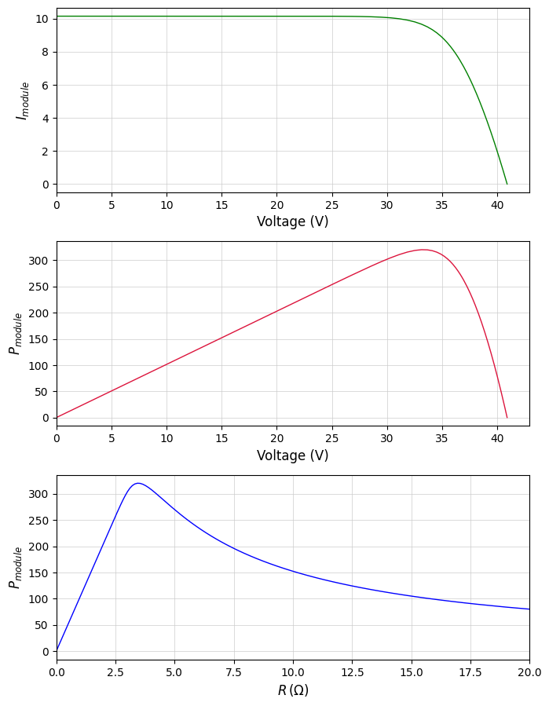

```python
import numpy as np
import matplotlib.pyplot as plt
import gseim_calc as calc
from setsize import set_size

slv = calc.slv("solar_1.in")

i_slv = 0
i_out = 0
filename = slv.l_filename_all[i_slv][i_out]
print('filename:', filename)
u = np.loadtxt(filename)
t = u[:, 0]

p_module = slv.get_array_double(i_slv,i_out,"p_module",u)
r1       = slv.get_array_double(i_slv,i_out,"r1"  ,u)
v_p      = slv.get_array_double(i_slv,i_out,"v_p"   ,u)
i1       = slv.get_array_double(i_slv,i_out,"i1"   ,u)

p_max = np.max(p_module)
k_max = p_module.argmax()
r1_max_power = r1[k_max]

print('R for max power:', "%11.4E"%r1_max_power, "ohms")
print('max power:', "%11.4E"%p_max, "W")

color1='green'
color2='crimson'
color3='blue'

fig, ax = plt.subplots(3, sharex=False)
plt.subplots_adjust(wspace=0, hspace=0.0)

set_size(5.5, 7, ax[0])

for i in range(3):
    ax[i].grid(color='#CCCCCC', linestyle='solid', linewidth=0.5)

ax[0].plot(v_p, i1      , color=color1, linewidth=1.0, label="$I_{module}$")
ax[1].plot(v_p, p_module, color=color2, linewidth=1.0, label="$P_{module}$")
ax[2].plot(r1 , p_module, color=color3, linewidth=1.0, label="$P_{module}$")

ax[0].set_ylabel(r'$I_{module}$', fontsize=12)
ax[1].set_ylabel(r'$P_{module}$', fontsize=12)
ax[2].set_ylabel(r'$P_{module}$', fontsize=12)

ax[0].set_xlabel('Voltage (V)'   , fontsize=12)
ax[1].set_xlabel('Voltage (V)'   , fontsize=12)
ax[2].set_xlabel(r'$R\,(\Omega)$', fontsize=12)

ax[0].set_xlim(left=0.0)
ax[1].set_xlim(left=0.0)
ax[2].set_xlim(left=0.0, right=20.0)

plt.tight_layout()
plt.show()
```

This notebook was contributed by **Prof. Nakul Narayanan K**, Govt. Engineering College, Thrissur. He may be contacted at nakul@gectcr.ac.in.